# dz12

Goran Brlas

2/8/2018

1. Učitajte i proučite podatkovni skup diamonds koji dolazi zajedno s paketom ggplot2.

```r
data(diamonds)
```

1. Prikažite raspodjelu cijene dijamanata uz pomoć dva grafa - histograma i tzv. frekvencijskih poligona (funkcija geom_freqpoly)). Cijene podijelite u 10 ladica.

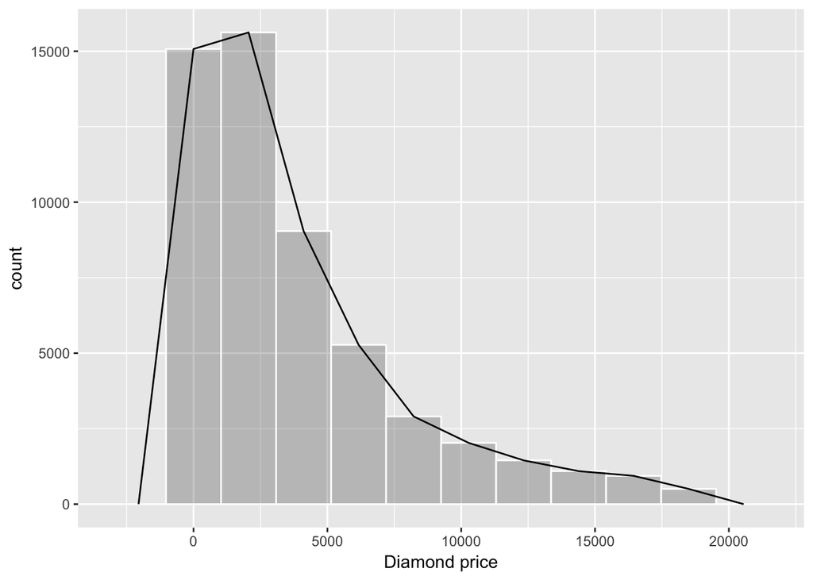

```r
ggplot(diamonds, aes(price)) +
  geom_histogram(bins=10,color="White",alpha=0.3) +
  geom_freqpoly(bins=10) +
  labs(x="Diamond price")
```

2. Grafovima iz a) dodajte “čistoću” dijamanta (stupac clarity) koji ćete postaviti na fill estetiku (histogram) odnosno color estetiku (frekvencijski poligoni). Koju razliku između grafova uočavate obzirom na default-ni aspekt pozicije?

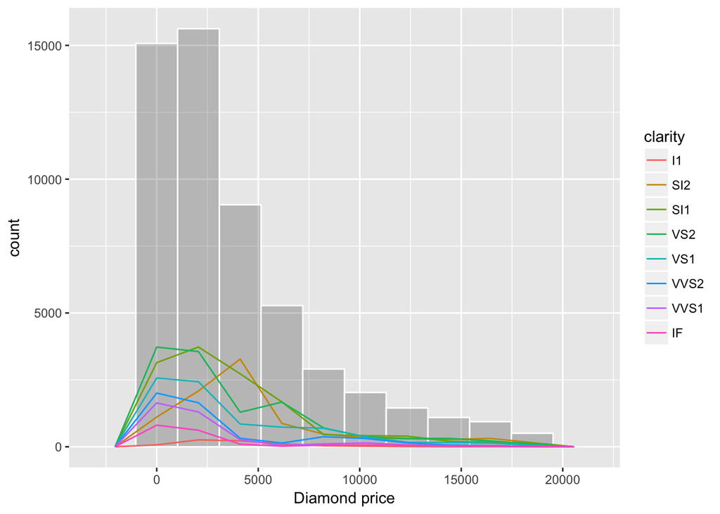

```r
ggplot(diamonds, aes(price, colour = clarity)) +
  geom_histogram(bins=10,color="White",alpha=0.3) +
  geom_freqpoly(bins=10) +
  labs(x="Diamond price")
```

2. Učitajte i proučite podatkovni skup mpg. Pokušajte rekonstruirati sljedeće grafove. Nepoznate geometrije identificirajte uz pomoć podsjetnika.

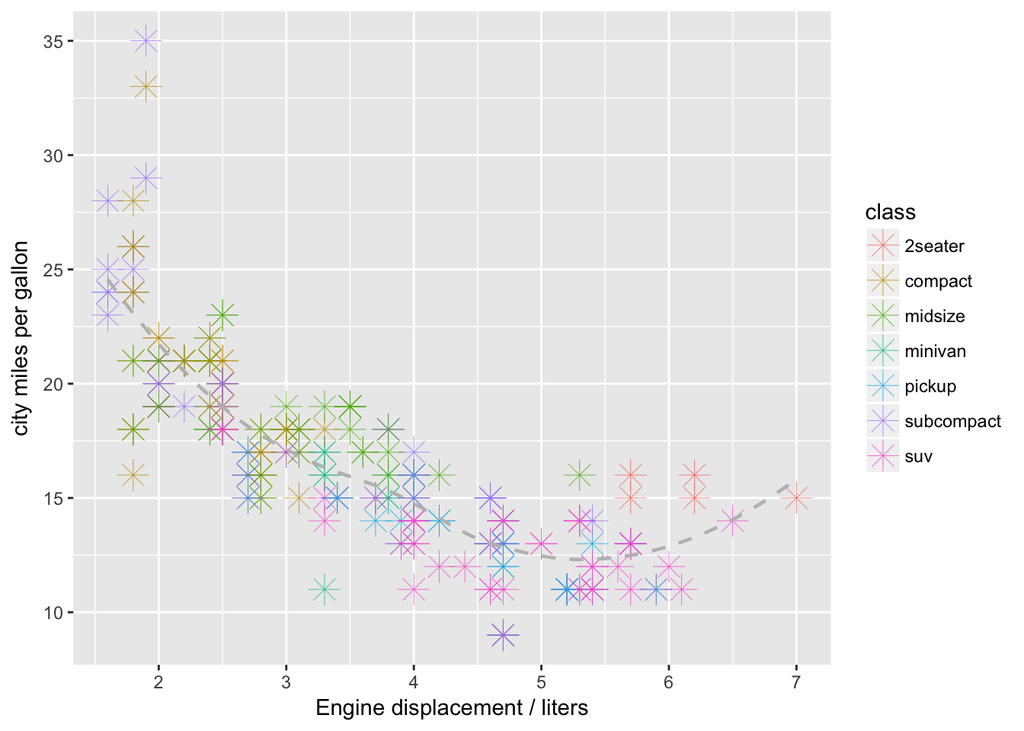

```r
ggplot(mpg, aes(x = displ, y = cty))  + geom_point(aes(color = class),shape = 8, size = 5, stroke= 0.2 ) +
  stat_smooth(method = 'loess', se = FALSE, linetype = "dashed", color = "Gray", size = 0.8)+
  labs(x="Engine displacement / liters", y = "city miles per gallon")
```

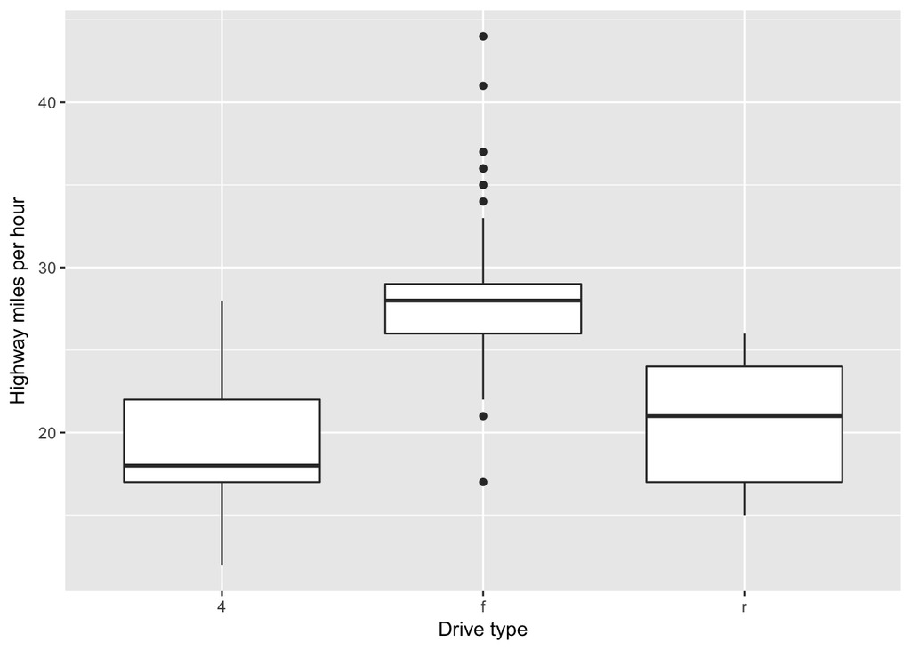

```r
ggplot(mpg, aes(x = as.factor(drv), y = hwy)) + geom_boxplot() +
  labs(x="Drive type", y = "Highway miles per hour")
```

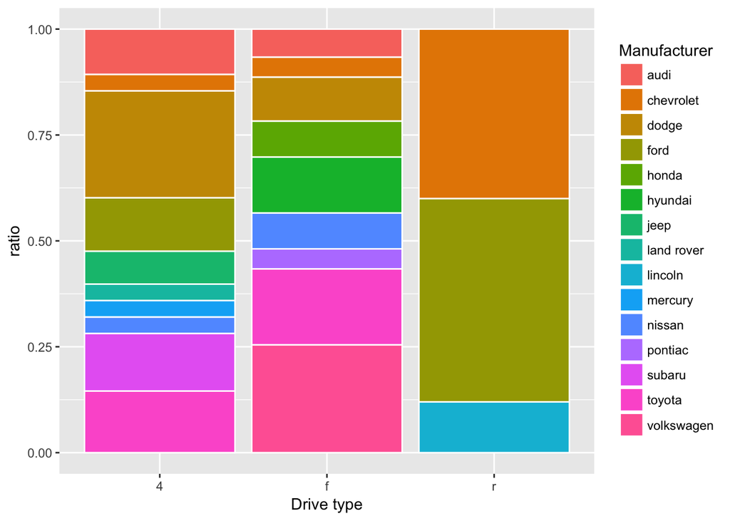

```r
ggplot() + geom_bar(data = mpg,aes(x = factor(drv),fill = factor(manufacturer)),position = "fill", color="White") +
  scale_fill_discrete(name = "Manufacturer") +
  labs(x="Drive type", y="ratio")
```

3. Uz pomoć funkcija skaliranja na sljedećem grafu:
1. os x nazovite “broj cilindara”
2. os y nazovite “ukupno” i povećajte raspon do 100
3. legendu za godine nazovite “godina”
4. za boju pravokutnika odaberite paletu “Dark2”

[output not shown]

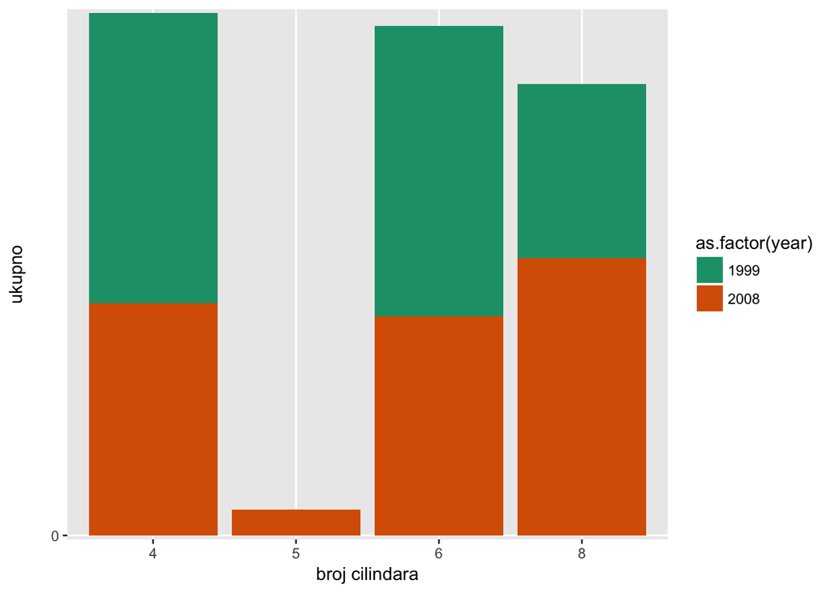

```r
ggplot(mpg, aes(x = as.factor(cyl), fill = as.factor(year))) + geom_bar() + scale_x_discrete(name = "broj cilindara") + scale_y_discrete(name = "ukupno", limits = c(0, 100)) + scale_fill_discrete(name = "New Legend Title") + scale_fill_brewer(palette = "Dark2")
```

4. Promijenite temu sljedećeg grafa na sljedeći način: a) prilagodite prikaz projekciji na platno b) okrenite nazive na x osi vertikalno

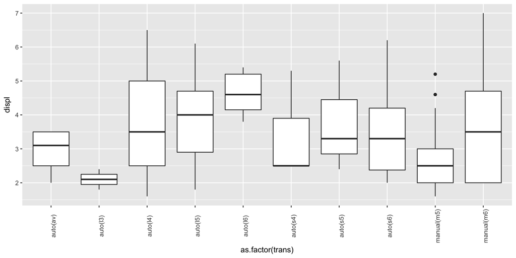

```r
ggplot(mpg, aes(x = as.factor(trans), y = displ)) +
  geom_boxplot() + theme(axis.text.x = element_text(angle = 90))
```

5. Sljedeći graf prikazuje histogram potrošnje na autocesti pri čemu boja pravokutnika odražava broj cilindara. Pokušajte poboljšati interpretabilnost grafa tako da estetiku boje zamijenite prikazom više grafova uvjetovanih brojem cilindara. Grafove organizirajte u matricu 2 x 2.

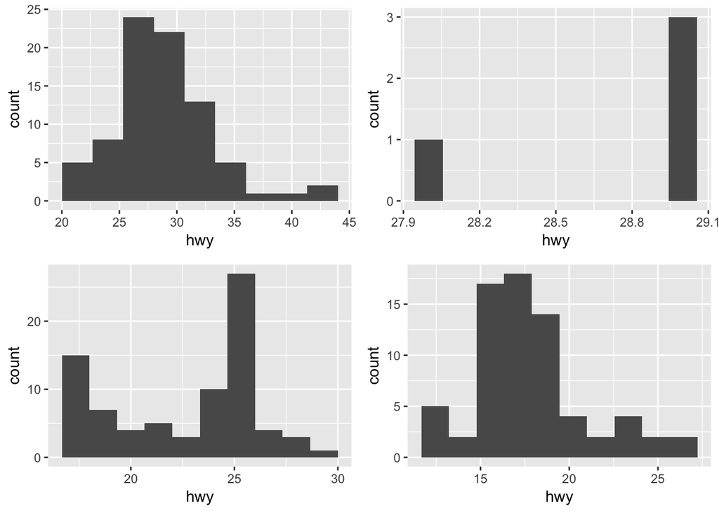

```r
g1 <- ggplot(mpg[mpg$cyl == 4,], aes(hwy)) +
  geom_histogram(bins = 10)
g2 <- ggplot(mpg[mpg$cyl == 5,], aes(hwy)) +
  geom_histogram(bins = 10)
g3 <- ggplot(mpg[mpg$cyl == 6,], aes(hwy)) +
  geom_histogram(bins = 10)
g4 <- ggplot(mpg[mpg$cyl == 8,], aes(hwy)) +
  geom_histogram(bins = 10)
grid.arrange(g1, g2, g3, g4, nrow = 2, ncol = 2)
```

6. Pretpostavimo da imamo sljedeći podatkovni okvir:

```r
prodaja <- data.frame(mjesec = 1:12,
          ukupno = c(10000, 5000, 12000, 3000, 5000, 7000,
                   10000, 2000, 4000, 8000, 11000, 14000))
```

i da ga želimo predočiti stupčastim grafom (engl. bar chart), no funkcija geom_bar po default-u radi sa samo jednom varijablom za koju računa sumarne statistike. Kako riješiti ovaj problem? Predložite rješenje i stvorite odgovarajući stupčasti graf.

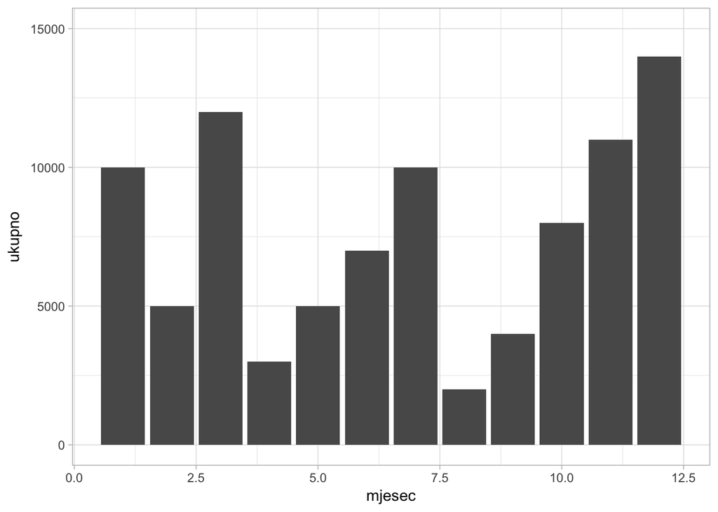

```r
ggplot(prodaja) + geom_bar(aes(x = mjesec, y=ukupno),stat="identity") + ylim(0,15000) + theme_light()
```